# Untitled

Authors

16/11/2022

(in bocca al lupo!)

```
##                  2.5 %    97.5 %
## (Intercept) -866.35411 934.80481
## x             15.10888  24.12508
```

### Esercizio 1

Si è stimato un modello di regressione lineare semplice usando un campione di 15 osservazioni, ottenendo:
$$y = 34.225+ \underset{(2.087)}{19.617} x$$
La stima intervallare per $\beta_2$ a un livello di confidenza $\alpha = 0.95$ è:

1. [ 15.109 ; 24.125 ]
2. [ 15.141 ; 24.09 ]
3. [ 15.527 ; 23.707 ]
4. nessuna delle precedenti

Motivare:

### Esercizio 2

L’intervallo di confidenza [ 15.109 ; 24.125 ] :

1. ha una probabilità pari a 0.95 di contenere $\beta_2$
2. ha una probabilità pari a 0.95 di contenere $\hat\beta_2$
3. ha una probabilità pari a 0.05 di non contenere $\hat\beta_2$
4. nessuna delle precedenti

Motivare:

### Esercizio 3

Sia dato il modello
$$y_i = \beta_0 + \beta_1 \log(x_i) + u_i$$

A quanto è associato un incremento di $x$ pari a 1% nella variabile $y$?

### Esercizio 4

Si è stimato il seguente modello di regressione

$$\hat{TestScore} = 664.1 - 1.9 HiSTR - 18.2 Hiel - 3.5(Histr\times Hiel)$$

dove

- $HiSTR_i$ è una variabile binaria uguale a 1 se il rapporto studenti insegnanti nel quartiere è maggiore o uguale a 20 e 0 altrimenti.
- $HiEL$ è una variabile binaria uguale a 1 se la percentuale di quelli che stanno imparando la lingua è maggiore o uguale a 10% e 0 altrimenti.

Qual è l’effetto predetto su $TestScore$ spostandoci da un quartiere con un basso rapporto studenti-insegnanti a uno con alto (a parità di $Hiel$) ? Motivare

### Esercizio 5

La maggior parte della ricerca in economia appare prima nelle riviste di economia, per questo gli economisti - o le biblioteche del dipartimento - si abbonano a queste riviste. Poiché il prodotto di una rivista sta più nelle idee che contiene e non nel prezzo, ed essendo difficile misurare le idee, per stimare l’elasticità della domanda al prezzo si utilizza il seguente modello di regressione

$$\log(subscription_i) = \beta_0 + \beta_1 \log(\text{ price per citation}_i) + u_i$$

da cui si ottiene $\hat\beta_1 = -0.533$, $\hat{se}(\hat\beta_1) = 0.034$

Qual è l’elasticità della domanda?

### Esercizio 6

Si è stimato successivamente il modello ($n = 180$)

$$\log(subscription_i) = int.\underset{(0.160)}{-0.961} \log(\text{price cit.}_i) + \underset{(0.025)}{0.017} \log(\text{price cit.}^2_i) + \underset{(0.0055)}{0.0037} \log(\text{price cit.}^3_i) + \underset{(0.118)}{0.373}\log(age_i)+ u_i$$

(dove price cit. è una abbreviazione di price per citation). Si vuole verificare l’ipotesi che $\log(\text{ price per citation})$ entri nel modello solo in modo lineare e non con le sue potenze 2 e 3.

Scrivere l’ipotesi che si vuole verificare e a statistica Test da usare

### Esercizio 7

Sulla base di quanto visto prima. Se il valore della statistica test fosse 0.25 con p-valore pari a 0.77, che cosa si può concludere?

### Esercizio 8

Si è stimato il seguente modello del mercato del lavoro

$$\log(wage_i) = \beta_0 + \beta_1 exper_i + \beta_2 exper_i^2 + age_i + e_i$$

```
##
## Call:
## lm(formula = logWage ~ exper + I(exper^2) + age)
##
## Residuals:
##      Min       1Q   Median       3Q      Max
## -0.29405 -0.06751  0.01097  0.06464  0.16708
##
## Coefficients:
##               Estimate Std. Error t value Pr(>|t|)
## (Intercept)  2.9830577  0.0532659  56.003   <2e-16 ***
## exper       -0.0135269  0.0099506  -1.359    0.177
## I(exper^2)   0.0011619  0.0007551   1.539    0.127
## age          0.0005461  0.0008744   0.625    0.534
## ---
## Signif. codes:  0 '***' 0.001 '**' 0.01 '*' 0.05 '.' 0.1 ' ' 1
##
## Residual standard error: 0.09444 on 96 degrees of freedom
## Multiple R-squared:  0.02924,    Adjusted R-squared:  -0.001093
## F-statistic: 0.964 on 3 and 96 DF,  p-value: 0.4131
```

Quali dei coefficienti sono statisticamente significativi?

### Esercizio 9

Sulla base del risultato dell’esercizio 8, Il modello è statisticamente significativo? Scrivere

1. l’ipotesi che si sta verificando
2. la statistica test di riferimento
3. il risultato della decisione inferenziale

### Esercizio 10

Sia
$$y = \beta_0 + \beta_1 x + e$$
un generico modello di regressione e sia la figura sottostante il grafico dei residui. Si scelga quale tra le seguenti affermazioni è corretta:

1. I residui sono eteroschedastici perché $\hat \sigma^2_i = \sigma^2$.
2. i residui sono eteroschedastici perché $\hat \sigma^2_i = f(x_i)$
3. i residui sono omoschedastici
4. non è il grafico con cui si dovrebbe testare l’ipotesi

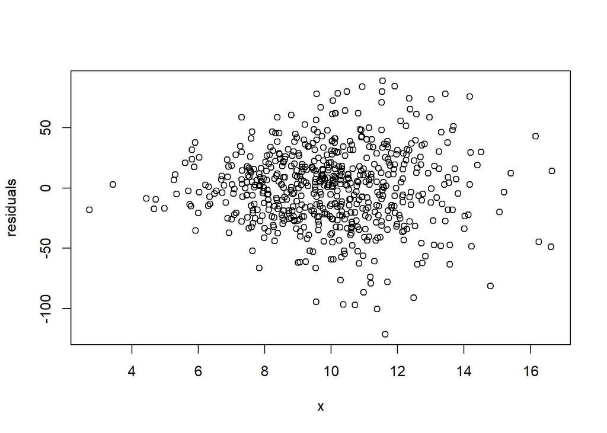

### Esercizio 11

Si riporta il test di Jarque bera.

```
##
##  Jarque Bera Test
##
## data:  e.hat
## X-squared = 11.808, df = 2, p-value = 0.002729
```

1. i residui non sono normali
2. i residui sono normali
3. i residui sono normali ma eteroschedastici
4. nessuna delle precedenti

### Esercizio 12

Si vuole verificare l’effetto di una tassa sulla birra sul tasso di mortalità di incidenti autostradali stimando il modello

$$TassoMort_{it} = \beta_{1i} + \beta_{2}TassaBirra_{it} + e_{it}$$

Quale stimatore è necessario utilizzare data la specificazione?

1. pooled
2. effetti fissi
3. effetti random
4. Hausman-Tailor